# 566hw1

```r
#install.packages("data.table")
#install.packages("leaflet")
library(data.table)
library(leaflet)
library(tidyverse)
PMdata2004 <- data.table::fread("/Users/jiqingwu/Desktop/566 Introduction to Health Data Science/hw1/2004California.csv")
PMdata2019 <- data.table::fread("/Users/jiqingwu/Desktop/566 Introduction to Health Data Science/hw1/2019California.csv")
```

##1

```r
#2004
dim(PMdata2004)
```

```
## [1] 19233    20
```

```r
head(PMdata2004)
```

```
##          Date Source  Site ID POC Daily Mean PM2.5 Concentration    UNITS
## 1: 01/01/2004    AQS 60010007   1                            8.9 ug/m3 LC
## 2: 01/02/2004    AQS 60010007   1                           12.2 ug/m3 LC
## 3: 01/03/2004    AQS 60010007   1                           16.5 ug/m3 LC
## 4: 01/04/2004    AQS 60010007   1                           19.5 ug/m3 LC
## 5: 01/05/2004    AQS 60010007   1                           11.5 ug/m3 LC
## 6: 01/06/2004    AQS 60010007   1                           32.5 ug/m3 LC
##    DAILY_AQI_VALUE Site Name DAILY_OBS_COUNT PERCENT_COMPLETE
## 1:              37 Livermore               1              100
## 2:              51 Livermore               1              100
## 3:              60 Livermore               1              100
## 4:              67 Livermore               1              100
## 5:              48 Livermore               1              100
## 6:              94 Livermore               1              100
##    AQS_PARAMETER_CODE                     AQS_PARAMETER_DESC CBSA_CODE
```

[output cut: 20 more lines]

```r
tail(PMdata2004)
```

```
##          Date Source  Site ID POC Daily Mean PM2.5 Concentration    UNITS
## 1: 12/14/2004    AQS 61131003   1                             11 ug/m3 LC
## 2: 12/17/2004    AQS 61131003   1                             16 ug/m3 LC
## 3: 12/20/2004    AQS 61131003   1                             17 ug/m3 LC
## 4: 12/23/2004    AQS 61131003   1                              9 ug/m3 LC
## 5: 12/26/2004    AQS 61131003   1                             24 ug/m3 LC
## 6: 12/29/2004    AQS 61131003   1                              9 ug/m3 LC
##    DAILY_AQI_VALUE            Site Name DAILY_OBS_COUNT PERCENT_COMPLETE
## 1:              46 Woodland-Gibson Road               1              100
## 2:              59 Woodland-Gibson Road               1              100
## 3:              61 Woodland-Gibson Road               1              100
## 4:              38 Woodland-Gibson Road               1              100
## 5:              76 Woodland-Gibson Road               1              100
## 6:              38 Woodland-Gibson Road               1              100
##    AQS_PARAMETER_CODE       AQS_PARAMETER_DESC CBSA_CODE
```

[output cut: 20 more lines]

```r
str(PMdata2004)
```

```
## Classes 'data.table' and 'data.frame':   19233 obs. of  20 variables:
##  $ Date                          : chr  "01/01/2004" "01/02/2004" "01/03/2004" "01/04/2004" ...
##  $ Source                        : chr  "AQS" "AQS" "AQS" "AQS" ...
##  $ Site ID                       : int  60010007 60010007 60010007 60010007 60010007 60010007 60010007 60010007 60010007 60010007 ...
##  $ POC                           : int  1 1 1 1 1 1 1 1 1 1 ...
##  $ Daily Mean PM2.5 Concentration: num  8.9 12.2 16.5 19.5 11.5 32.5 15.5 29.9 21 16.9 ...
##  $ UNITS                         : chr  "ug/m3 LC" "ug/m3 LC" "ug/m3 LC" "ug/m3 LC" ...
##  $ DAILY_AQI_VALUE               : int  37 51 60 67 48 94 58 88 70 61 ...
##  $ Site Name                     : chr  "Livermore" "Livermore" "Livermore" "Livermore" ...
##  $ DAILY_OBS_COUNT               : int  1 1 1 1 1 1 1 1 1 1 ...
##  $ PERCENT_COMPLETE              : num  100 100 100 100 100 100 100 100 100 100 ...
##  $ AQS_PARAMETER_CODE            : int  88101 88502 88502 88502 88502 88502 88502 88502 88502 88502 ...
##  $ AQS_PARAMETER_DESC            : chr  "PM2.5 - Local Conditions" "Acceptable PM2.5 AQI & Speciation Mass" "Acceptable PM2.5 AQI & Speciation Mass" "Acceptable PM2.5 AQI & Speciation Mass" ...
##  $ CBSA_CODE                     : int  41860 41860 41860 41860 41860 41860 41860 41860 41860 41860 ...
##  $ CBSA_NAME                     : chr  "San Francisco-Oakland-Hayward, CA" "San Francisco-Oakland-Hayward, CA" "San Francisco-Oakland-Hayward, CA" "San Francisco-Oakland-Hayward, CA" ...
##  $ STATE_CODE                    : int  6 6 6 6 6 6 6 6 6 6 ...
##  $ STATE                         : chr  "California" "California" "California" "California" ...
##  $ COUNTY_CODE                   : int  1 1 1 1 1 1 1 1 1 1 ...
##  $ COUNTY                        : chr  "Alameda" "Alameda" "Alameda" "Alameda" ...
##  $ SITE_LATITUDE                 : num  37.7 37.7 37.7 37.7 37.7 ...
##  $ SITE_LONGITUDE                : num  -122 -122 -122 -122 -122 ...
##  - attr(*, ".internal.selfref")=<externalptr>
```

```r
names(PMdata2004)<-str_replace_all(names(PMdata2004), c(" " = "." , "," = "" ))

summary(PMdata2004$Daily.Mean.PM2.5.Concentration)
```

```
##    Min. 1st Qu.  Median    Mean 3rd Qu.    Max.
##   -0.10    6.00   10.10   13.13   16.30  251.00
```

```r
summary(PMdata2004$DAILY_AQI_VALUE)
```

```
##    Min. 1st Qu.  Median    Mean 3rd Qu.    Max.
##    0.00   25.00   42.00   46.32   60.00  301.00
```

```r
table(PMdata2004$Date)
```

```
##
## 01/01/2004 01/02/2004 01/03/2004 01/04/2004 01/05/2004 01/06/2004 01/07/2004
##         80         23         22        108         19         22         89
## 01/08/2004 01/09/2004 01/10/2004 01/11/2004 01/12/2004 01/13/2004 01/14/2004
##         26         25        128         25         24         96         23
## 01/15/2004 01/16/2004 01/17/2004 01/18/2004 01/19/2004 01/20/2004 01/21/2004
##         23        116         25         26         80         20         22
## 01/22/2004 01/23/2004 01/24/2004 01/25/2004 01/26/2004 01/27/2004 01/28/2004
##        123         23         24         88         23         24        122
## 01/29/2004 01/30/2004 01/31/2004 02/01/2004 02/02/2004 02/03/2004 02/04/2004
##         28         26         90         24         23        121         20
## 02/05/2004 02/06/2004 02/07/2004 02/08/2004 02/09/2004 02/10/2004 02/11/2004
##         23         82         25         24        120         21         25
## 02/12/2004 02/13/2004 02/14/2004 02/15/2004 02/16/2004 02/17/2004 02/18/2004
##         86         23         25        120         22         21         83
## 02/19/2004 02/20/2004 02/21/2004 02/22/2004 02/23/2004 02/24/2004 02/25/2004
##         21         23        122         24         23         91         22
## 02/26/2004 02/27/2004 02/28/2004 02/29/2004 03/01/2004 03/02/2004 03/03/2004
##         24        115         26         25         81         23         24
## 03/04/2004 03/05/2004 03/06/2004 03/07/2004 03/08/2004 03/09/2004 03/10/2004
##        128         25         26         91         24         24        117
## 03/11/2004 03/12/2004 03/13/2004 03/14/2004 03/15/2004 03/16/2004 03/17/2004
##         21         21         86         24         22        122         21
## 03/18/2004 03/19/2004 03/20/2004 03/21/2004 03/22/2004 03/23/2004 03/24/2004
##         25         92         25         25        124         23         24
## 03/25/2004 03/26/2004 03/27/2004 03/28/2004 03/29/2004 03/30/2004 03/31/2004
##         91         24         23        127         23         22         86
## 04/01/2004 04/02/2004 04/03/2004 04/04/2004 04/05/2004 04/06/2004 04/07/2004
##         19         20        123         18         16         84         19
## 04/08/2004 04/09/2004 04/10/2004 04/11/2004 04/12/2004 04/13/2004 04/14/2004
##         21        117         21         21         71         18         17
## 04/15/2004 04/16/2004 04/17/2004 04/18/2004 04/19/2004 04/20/2004 04/21/2004
##        123         17         18         79         17         19        125
## 04/22/2004 04/23/2004 04/24/2004 04/25/2004 04/26/2004 04/27/2004 04/28/2004
##         20         19         82         20         20        126         21
## 04/29/2004 04/30/2004 05/01/2004 05/02/2004 05/03/2004 05/04/2004 05/05/2004
##         20         83         19         20        123         17         18
## 05/06/2004 05/07/2004 05/08/2004 05/09/2004 05/10/2004 05/11/2004 05/12/2004
##         82         19         19        126         18         19         85
## 05/13/2004 05/14/2004 05/15/2004 05/16/2004 05/17/2004 05/18/2004 05/19/2004
```

[output cut: 52 more lines]

```
##        136         31         31         99         31         33        127
## 11/18/2004 11/19/2004 11/20/2004 11/21/2004 11/22/2004 11/23/2004 11/24/2004
##         32         33        102         32         32        129         31
## 11/25/2004 11/26/2004 11/27/2004 11/28/2004 11/29/2004 11/30/2004 12/01/2004
##         33         99         31         30        121         30         31
## 12/02/2004 12/03/2004 12/04/2004 12/05/2004 12/06/2004 12/07/2004 12/08/2004
##         92         29         34        125         31         33         91
## 12/09/2004 12/10/2004 12/11/2004 12/12/2004 12/13/2004 12/14/2004 12/15/2004
##         34         32        131         30         30        106         31
## 12/16/2004 12/17/2004 12/18/2004 12/19/2004 12/20/2004 12/21/2004 12/22/2004
##         30        115         33         31         95         32         29
## 12/23/2004 12/24/2004 12/25/2004 12/26/2004 12/27/2004 12/28/2004 12/29/2004
##        130         30         33         90         31         32        129
## 12/30/2004 12/31/2004
##         32         35
```

```r
table(PMdata2004$Site.Name)
```

```
##
##
##                                               229
##                           3425 N FIRST ST, FRESNO
##                                               521
##                                           Anaheim
##                                               418
##                             Aqua Tibia Wilderness
##                                               109
##                        Atascadero (original site)
##                                               117
##                                             Azusa
##                                               279
##                       Bakersfield-Airport (Planz)
##                                               100
##                            Bakersfield-California
##                                               850
##                           Bakersfield-Golden/M St
##                                                88
##                                          Big Bear
##                                                52
##                                          Bliss SP
##                                               119
##                           Brawley-220 Main Street
##                                                99
##                                           Burbank
##                                               109
##                             Calexico-Ethel Street
##                                               162
##                              Chico-Manzanita Ave.
##                                               122
##                                       Chula Vista
##                                               113
##                                      Clovis-Villa
##                                                90
##                               Colusa-Sunrise Blvd
##                                               201
##                                           Concord
##                                               259
##                                Corcoran-Patterson
```

[output cut: 156 more lines]

```
##                                                61
##                                           Vallejo
##                                               361
##                           Victorville-Park Avenue
##                                               182
##                                    Visalia-Church
##                                               515
##                              Woodland-Gibson Road
##                                               116
##                     Yosemite NP - Turtleback Dome
##                                               110
##        Yosemite NP-Yosemite Village Vistor Center
##                                               210
##                                         Yuba City
##                                               309
```

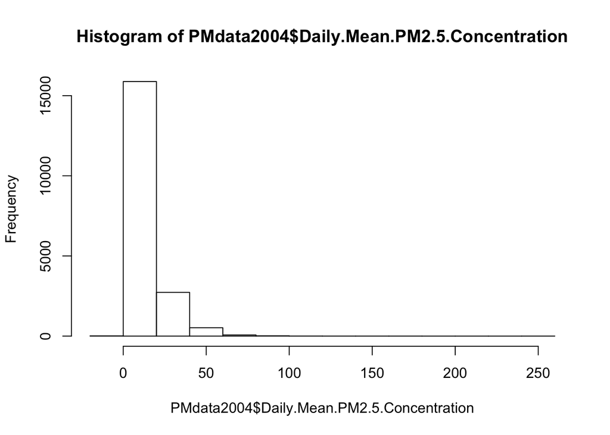

```r
hist(PMdata2004$Daily.Mean.PM2.5.Concentration)
```

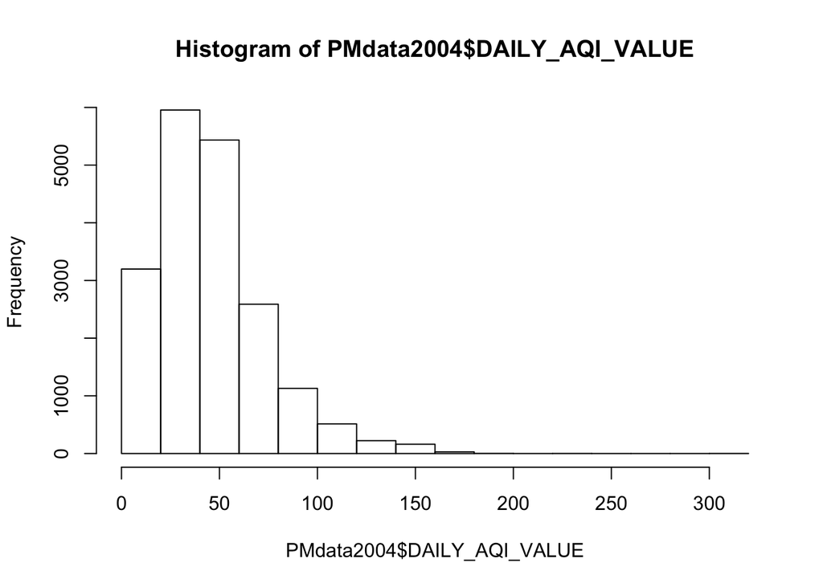

```r
hist(PMdata2004$DAILY_AQI_VALUE)
```

The maxium value of mean PM2.5 concentration is 251. The median is 10.10 and mean is 13.13 which means in general,daily mean PM2.5 concentration in Californai in 2004 is not very high.

```r
#2019
dim(PMdata2019)
```

```
## [1] 53328    20
```

```r
head(PMdata2019)
```

```
##          Date Source  Site ID POC Daily Mean PM2.5 Concentration    UNITS
## 1: 01/01/2019    AQS 60010007   3                            5.7 ug/m3 LC
## 2: 01/02/2019    AQS 60010007   3                           11.9 ug/m3 LC
## 3: 01/03/2019    AQS 60010007   3                           20.1 ug/m3 LC
## 4: 01/04/2019    AQS 60010007   3                           28.8 ug/m3 LC
## 5: 01/05/2019    AQS 60010007   3                           11.2 ug/m3 LC
## 6: 01/06/2019    AQS 60010007   3                            2.7 ug/m3 LC
##    DAILY_AQI_VALUE Site Name DAILY_OBS_COUNT PERCENT_COMPLETE
## 1:              24 Livermore               1              100
## 2:              50 Livermore               1              100
## 3:              68 Livermore               1              100
## 4:              86 Livermore               1              100
## 5:              47 Livermore               1              100
## 6:              11 Livermore               1              100
##    AQS_PARAMETER_CODE       AQS_PARAMETER_DESC CBSA_CODE
```

[output cut: 20 more lines]

```r
tail(PMdata2019)
```

```
##          Date Source  Site ID POC Daily Mean PM2.5 Concentration    UNITS
## 1: 11/11/2019    AQS 61131003   1                           13.5 ug/m3 LC
## 2: 11/17/2019    AQS 61131003   1                           18.1 ug/m3 LC
## 3: 11/29/2019    AQS 61131003   1                           12.5 ug/m3 LC
## 4: 12/17/2019    AQS 61131003   1                           23.8 ug/m3 LC
## 5: 12/23/2019    AQS 61131003   1                            1.0 ug/m3 LC
## 6: 12/29/2019    AQS 61131003   1                            9.1 ug/m3 LC
##    DAILY_AQI_VALUE            Site Name DAILY_OBS_COUNT PERCENT_COMPLETE
## 1:              54 Woodland-Gibson Road               1              100
## 2:              64 Woodland-Gibson Road               1              100
## 3:              52 Woodland-Gibson Road               1              100
## 4:              76 Woodland-Gibson Road               1              100
## 5:               4 Woodland-Gibson Road               1              100
## 6:              38 Woodland-Gibson Road               1              100
##    AQS_PARAMETER_CODE       AQS_PARAMETER_DESC CBSA_CODE
```

[output cut: 20 more lines]

```r
str(PMdata2019)
```

```
## Classes 'data.table' and 'data.frame':   53328 obs. of  20 variables:
##  $ Date                          : chr  "01/01/2019" "01/02/2019" "01/03/2019" "01/04/2019" ...
##  $ Source                        : chr  "AQS" "AQS" "AQS" "AQS" ...
##  $ Site ID                       : int  60010007 60010007 60010007 60010007 60010007 60010007 60010007 60010007 60010007 60010007 ...
##  $ POC                           : int  3 3 3 3 3 3 3 3 3 3 ...
##  $ Daily Mean PM2.5 Concentration: num  5.7 11.9 20.1 28.8 11.2 2.7 2.8 7 3.1 7.1 ...
##  $ UNITS                         : chr  "ug/m3 LC" "ug/m3 LC" "ug/m3 LC" "ug/m3 LC" ...
##  $ DAILY_AQI_VALUE               : int  24 50 68 86 47 11 12 29 13 30 ...
##  $ Site Name                     : chr  "Livermore" "Livermore" "Livermore" "Livermore" ...
##  $ DAILY_OBS_COUNT               : int  1 1 1 1 1 1 1 1 1 1 ...
##  $ PERCENT_COMPLETE              : num  100 100 100 100 100 100 100 100 100 100 ...
##  $ AQS_PARAMETER_CODE            : int  88101 88101 88101 88101 88101 88101 88101 88101 88101 88101 ...
##  $ AQS_PARAMETER_DESC            : chr  "PM2.5 - Local Conditions" "PM2.5 - Local Conditions" "PM2.5 - Local Conditions" "PM2.5 - Local Conditions" ...
##  $ CBSA_CODE                     : int  41860 41860 41860 41860 41860 41860 41860 41860 41860 41860 ...
##  $ CBSA_NAME                     : chr  "San Francisco-Oakland-Hayward, CA" "San Francisco-Oakland-Hayward, CA" "San Francisco-Oakland-Hayward, CA" "San Francisco-Oakland-Hayward, CA" ...
##  $ STATE_CODE                    : int  6 6 6 6 6 6 6 6 6 6 ...
##  $ STATE                         : chr  "California" "California" "California" "California" ...
##  $ COUNTY_CODE                   : int  1 1 1 1 1 1 1 1 1 1 ...
##  $ COUNTY                        : chr  "Alameda" "Alameda" "Alameda" "Alameda" ...
##  $ SITE_LATITUDE                 : num  37.7 37.7 37.7 37.7 37.7 ...
##  $ SITE_LONGITUDE                : num  -122 -122 -122 -122 -122 ...
##  - attr(*, ".internal.selfref")=<externalptr>
```

```r
names(PMdata2019)<-str_replace_all(names(PMdata2019), c(" " = "." , "," = "" ))

summary(PMdata2019$Daily.Mean.PM2.5.Concentration)
```

```
##    Min. 1st Qu.  Median    Mean 3rd Qu.    Max.
##  -2.200   4.000   6.500   7.744   9.900 120.900
```

```r
summary(PMdata2019$DAILY_AQI_VALUE)
```

```
##    Min. 1st Qu.  Median    Mean 3rd Qu.    Max.
##     0.0    17.0    27.0    30.6    41.0   185.0
```

```r
table(PMdata2019$Date)
```

```
##
## 01/01/2019 01/02/2019 01/03/2019 01/04/2019 01/05/2019 01/06/2019 01/07/2019
##        125        117        175        125        124        152        122
## 01/08/2019 01/09/2019 01/10/2019 01/11/2019 01/12/2019 01/13/2019 01/14/2019
##        120        180        121        118        157        123        122
## 01/15/2019 01/16/2019 01/17/2019 01/18/2019 01/19/2019 01/20/2019 01/21/2019
##        178        125        125        155        125        122        182
## 01/22/2019 01/23/2019 01/24/2019 01/25/2019 01/26/2019 01/27/2019 01/28/2019
##        119        121        158        124        124        182        122
## 01/29/2019 01/30/2019 01/31/2019 02/01/2019 02/02/2019 02/03/2019 02/04/2019
##        124        166        125        125        192        123        123
## 02/05/2019 02/06/2019 02/07/2019 02/08/2019 02/09/2019 02/10/2019 02/11/2019
##        164        123        124        180        128        125        166
## 02/12/2019 02/13/2019 02/14/2019 02/15/2019 02/16/2019 02/17/2019 02/18/2019
##        126        127        193        127        129        168        126
## 02/19/2019 02/20/2019 02/21/2019 02/22/2019 02/23/2019 02/24/2019 02/25/2019
##        128        182        124        125        170        125        124
## 02/26/2019 02/27/2019 02/28/2019 03/01/2019 03/02/2019 03/03/2019 03/04/2019
##        192        124        121        169        129        131        194
## 03/05/2019 03/06/2019 03/07/2019 03/08/2019 03/09/2019 03/10/2019 03/11/2019
##        127        127        166        127        129        199        130
## 03/12/2019 03/13/2019 03/14/2019 03/15/2019 03/16/2019 03/17/2019 03/18/2019
##        133        174        128        125        189        127        125
## 03/19/2019 03/20/2019 03/21/2019 03/22/2019 03/23/2019 03/24/2019 03/25/2019
##        176        127        126        201        132        130        174
## 03/26/2019 03/27/2019 03/28/2019 03/29/2019 03/30/2019 03/31/2019 04/01/2019
##        130        130        192        130        130        178        130
## 04/02/2019 04/03/2019 04/04/2019 04/05/2019 04/06/2019 04/07/2019 04/08/2019
##        128        200        133        131        176        132        129
## 04/09/2019 04/10/2019 04/11/2019 04/12/2019 04/13/2019 04/14/2019 04/15/2019
##        192        130        126        172        131        131        200
## 04/16/2019 04/17/2019 04/18/2019 04/19/2019 04/20/2019 04/21/2019 04/22/2019
##        131        131        176        133        132        198        135
## 04/23/2019 04/24/2019 04/25/2019 04/26/2019 04/27/2019 04/28/2019 04/29/2019
##        135        175        131        129        204        127        127
## 04/30/2019 05/01/2019 05/02/2019 05/03/2019 05/04/2019 05/05/2019 05/06/2019
##        174        128        128        189        129        129        177
## 05/07/2019 05/08/2019 05/09/2019 05/10/2019 05/11/2019 05/12/2019 05/13/2019
##        129        128        201        127        128        174        123
## 05/14/2019 05/15/2019 05/16/2019 05/17/2019 05/18/2019 05/19/2019 05/20/2019
```

[output cut: 52 more lines]

```
##        131        130        180        131        131        207        129
## 11/19/2019 11/20/2019 11/21/2019 11/22/2019 11/23/2019 11/24/2019 11/25/2019
##        131        168        131        133        196        131        130
## 11/26/2019 11/27/2019 11/28/2019 11/29/2019 11/30/2019 12/01/2019 12/02/2019
##        171        132        130        202        131        126        156
## 12/03/2019 12/04/2019 12/05/2019 12/06/2019 12/07/2019 12/08/2019 12/09/2019
##        131        131        176        126        126        154        124
## 12/10/2019 12/11/2019 12/12/2019 12/13/2019 12/14/2019 12/15/2019 12/16/2019
##        123        184        126        121        156        125        124
## 12/17/2019 12/18/2019 12/19/2019 12/20/2019 12/21/2019 12/22/2019 12/23/2019
##        174        130        134        161        134        133        190
## 12/24/2019 12/25/2019 12/26/2019 12/27/2019 12/28/2019 12/29/2019 12/30/2019
##        134        133        157        127        126        180        124
## 12/31/2019
##        128
```

```r
table(PMdata2019$Site.Name)
```

```
##
##
##                                                93
##                                          29 Palms
##                                               300
##                                            Alpine
##                                               350
##                                           Anaheim
##                                               712
##                             Aqua Tibia Wilderness
##                                                79
##                                 Arroyo Grande CDF
##                                               356
##                                        Atascadero
##                                               359
##                                     Auburn-Atwood
##                                               353
##                                             Azusa
##                                               121
##                       Bakersfield-Airport (Planz)
##                                               115
##                            Bakersfield-California
##                                               748
##                           Bakersfield-Golden/M St
##                                               121
##                                   Banning Airport
##                                               365
##                             Berkeley Aquatic Park
##                                               352
##                                          Big Bear
##                                                46
##                                          Bliss SP
##                                                61
##                           Brawley-220 Main Street
##                                               117
##                             Calexico-Ethel Street
##                                               773
##                                    Camp Pendleton
##                                               350
##                                     Carmel Valley
```

[output cut: 266 more lines]

```
##                                               419
##                Willits-125 East Commercial Street
##                                               354
##                             Willows-Colusa Street
##                                               356
##                              Woodland-Gibson Road
##                                                53
##                     Yosemite NP - Turtleback Dome
##                                               196
##        Yosemite NP-Yosemite Village Vistor Center
##                                               333
##                                             Yreka
##                                               363
##                                         Yuba City
##                                               708
```

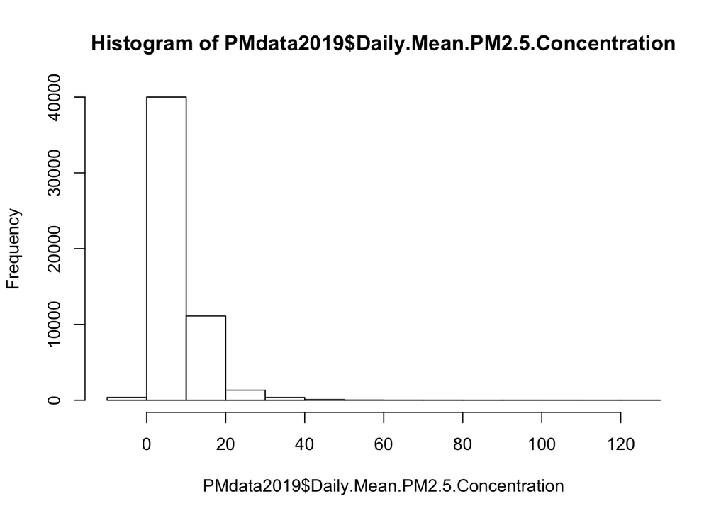

```r
hist(PMdata2019$Daily.Mean.PM2.5.Concentration)
```

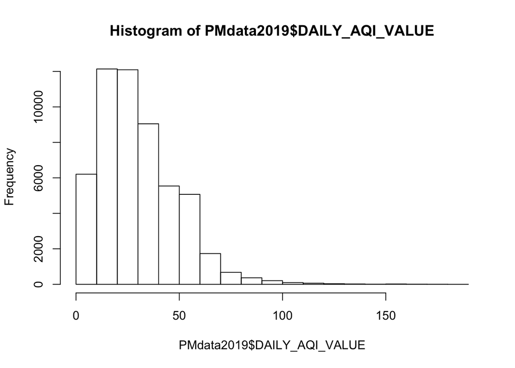

```r
hist(PMdata2019$DAILY_AQI_VALUE)
```

##2

```r
new2004<-PMdata2004
new2004$year<-rep(2004,nrow(new2004))

new2019<-PMdata2019
new2019$year<-rep(2019,nrow(new2019))

total <- rbind(new2004,new2019)
str(total)
```

```
## Classes 'data.table' and 'data.frame':   72561 obs. of  21 variables:
##  $ Date                          : chr  "01/01/2004" "01/02/2004" "01/03/2004" "01/04/2004" ...
##  $ Source                        : chr  "AQS" "AQS" "AQS" "AQS" ...
##  $ Site.ID                       : int  60010007 60010007 60010007 60010007 60010007 60010007 60010007 60010007 60010007 60010007 ...
##  $ POC                           : int  1 1 1 1 1 1 1 1 1 1 ...
##  $ Daily.Mean.PM2.5.Concentration: num  8.9 12.2 16.5 19.5 11.5 32.5 15.5 29.9 21 16.9 ...
##  $ UNITS                         : chr  "ug/m3 LC" "ug/m3 LC" "ug/m3 LC" "ug/m3 LC" ...
##  $ DAILY_AQI_VALUE               : int  37 51 60 67 48 94 58 88 70 61 ...
##  $ Site.Name                     : chr  "Livermore" "Livermore" "Livermore" "Livermore" ...
##  $ DAILY_OBS_COUNT               : int  1 1 1 1 1 1 1 1 1 1 ...
##  $ PERCENT_COMPLETE              : num  100 100 100 100 100 100 100 100 100 100 ...
##  $ AQS_PARAMETER_CODE            : int  88101 88502 88502 88502 88502 88502 88502 88502 88502 88502 ...
##  $ AQS_PARAMETER_DESC            : chr  "PM2.5 - Local Conditions" "Acceptable PM2.5 AQI & Speciation Mass" "Acceptable PM2.5 AQI & Speciation Mass" "Acceptable PM2.5 AQI & Speciation Mass" ...
##  $ CBSA_CODE                     : int  41860 41860 41860 41860 41860 41860 41860 41860 41860 41860 ...
##  $ CBSA_NAME                     : chr  "San Francisco-Oakland-Hayward, CA" "San Francisco-Oakland-Hayward, CA" "San Francisco-Oakland-Hayward, CA" "San Francisco-Oakland-Hayward, CA" ...
##  $ STATE_CODE                    : int  6 6 6 6 6 6 6 6 6 6 ...
##  $ STATE                         : chr  "California" "California" "California" "California" ...
##  $ COUNTY_CODE                   : int  1 1 1 1 1 1 1 1 1 1 ...
##  $ COUNTY                        : chr  "Alameda" "Alameda" "Alameda" "Alameda" ...
##  $ SITE_LATITUDE                 : num  37.7 37.7 37.7 37.7 37.7 ...
##  $ SITE_LONGITUDE                : num  -122 -122 -122 -122 -122 ...
##  $ year                          : num  2004 2004 2004 2004 2004 ...
##  - attr(*, ".internal.selfref")=<externalptr>
```

```r
names(total)[names(total) == "Daily.Mean.PM2.5.Concentration"] <- "PM2.5"
names(total)[names(total) == "DAILY_AQI_VALUE"] <- "AQI"
```

##3

```r
library(leaflet)
stations2004 <- (unique(new2004[,c("SITE_LATITUDE","SITE_LONGITUDE")]))
stations2019 <- (unique(new2019[,c("SITE_LATITUDE","SITE_LONGITUDE")]))

leaflet() %>%
  addProviderTiles('CartoDB.Positron') %>%
  addCircles(data=stations2004, lat=~SITE_LATITUDE,lng=~SITE_LONGITUDE, opacity=1, fillOpacity=1, radius=400, color="blue") %>%
  addCircles(data=stations2019, lat=~SITE_LATITUDE,lng=~SITE_LONGITUDE, opacity=1, fillOpacity=1, radius=400, color="red")
```

[interactive chart not shown]

##From the map,red dots(2019) is much more than blue dots(2004), and the distribution of red dots is more representative. This means that the research results of 2019 is more powerful than that in 2004.

##4

```r
summary(total$PM2.5)
```

```
##    Min. 1st Qu.  Median    Mean 3rd Qu.    Max.
##   -2.20    4.40    7.20    9.17   11.30  251.00
```

```r
summary(total$AQI)
```

```
##    Min. 1st Qu.  Median    Mean 3rd Qu.    Max.
##    0.00   18.00   30.00   34.77   47.00  301.00
```

```r
dim(total[PM2.5<=0])[1]/dim(total)[1]
```

```
## [1] 0.005292099
```

```r
newtotal<-total[PM2.5>=0]
summary(newtotal$PM2.5)
```

```
##    Min. 1st Qu.  Median    Mean 3rd Qu.    Max.
##   0.000   4.400   7.300   9.211  11.300 251.000
```

```r
summary(newtotal$AQI)
```

```
##    Min. 1st Qu.  Median    Mean 3rd Qu.    Max.
##    0.00   18.00   30.00   34.91   47.00  301.00
```

```r
dim(newtotal[is.na(PM2.5)])[1]/dim(newtotal)[1]
```

```
## [1] 0
```

```r
dim(newtotal[is.na(AQI)])[1]/dim(newtotal)[1]
```

```
## [1] 0
```

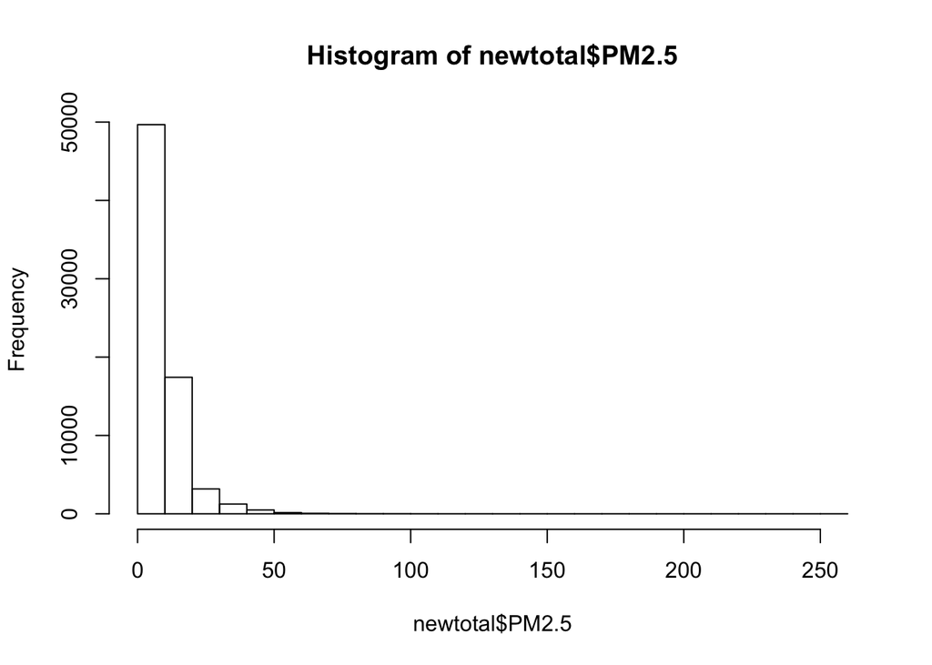

```r
hist(newtotal$PM2.5)
```

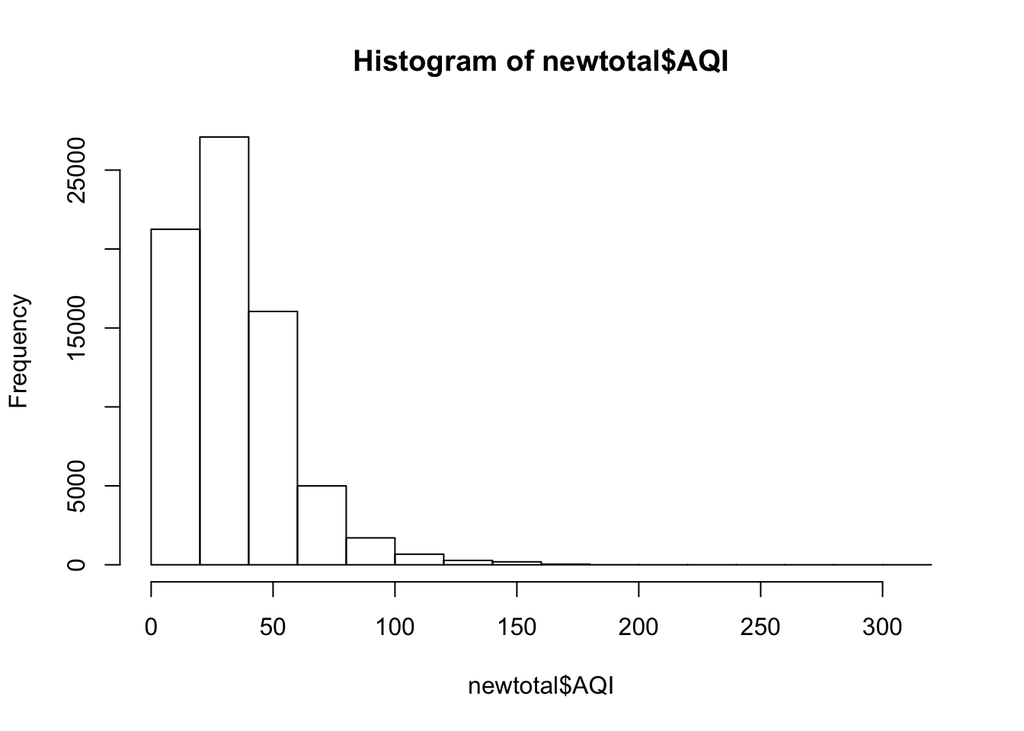

```r
hist(newtotal$AQI)
```

##The concentration of PM2.5 is impossible to be less than 0, the proportion is 0.529%. We need to remove all the obs less than 0. And there is no missing value in this dataset.

The overall distribution of PM2.5 concentration is not normally distributed. Most of the values are distributed from 0 to 20.

The overall distribution of daily AQI looks more normal. Most of data are distributed around 30.

##5

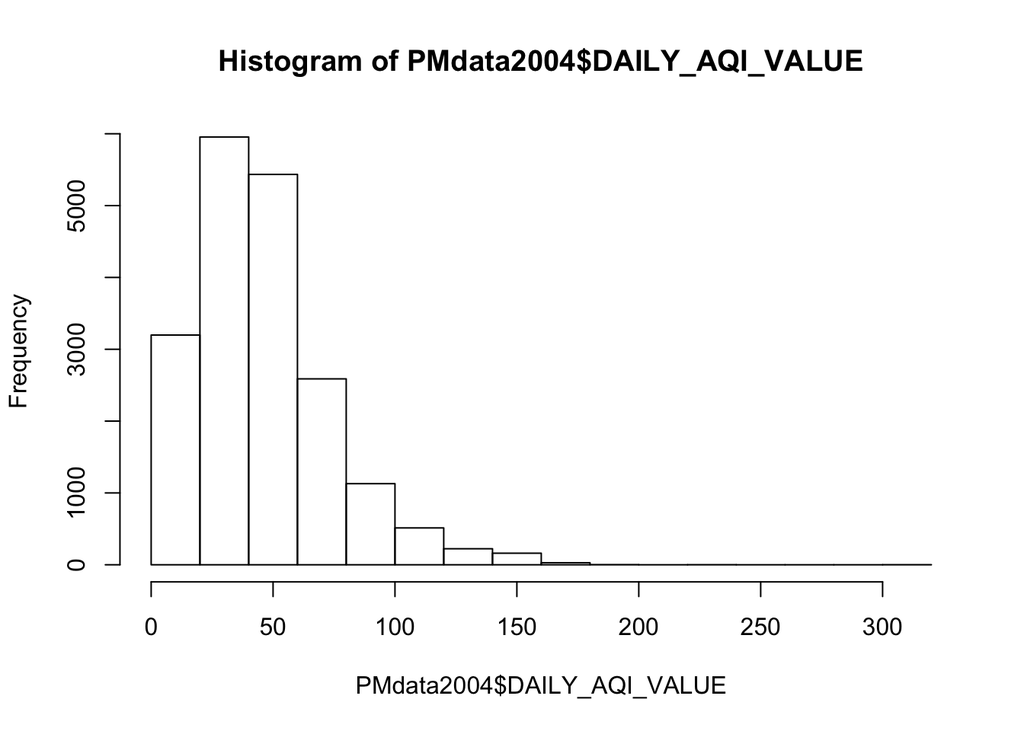

```r
#state
hist(PMdata2004$DAILY_AQI_VALUE)
```

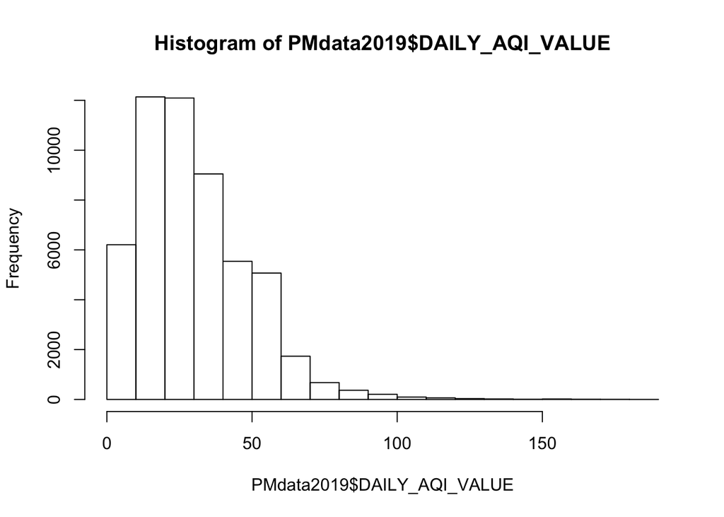

```r
hist(PMdata2019$DAILY_AQI_VALUE)
```

```r
mean(PMdata2004$DAILY_AQI_VALUE)
```

```
## [1] 46.32278
```

```r
mean(PMdata2019$DAILY_AQI_VALUE)
```

```
## [1] 30.60107
```

##Obviously, from the whole state, the mean AQI value decreased. The mean value decreased from 46.32278 in 2004 to 30.60107 in 2019, which means the air condition become better.

```r
#County

library(plyr)
```

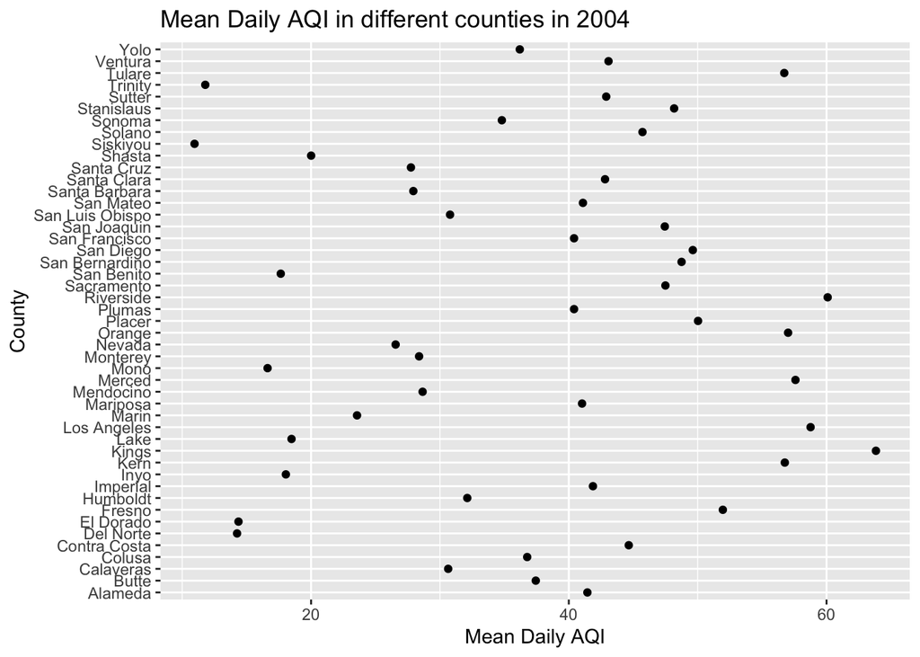

```r
Mean2004<-ddply(PMdata2004,.(COUNTY),summarize,meanValue=mean(DAILY_AQI_VALUE))
ggplot(data=Mean2004, aes(x=Mean2004$meanValue,y=Mean2004$COUNTY))+geom_point()+labs(title="Mean Daily AQI in different counties in 2004")+xlab("Mean Daily AQI")+ylab("County")
```

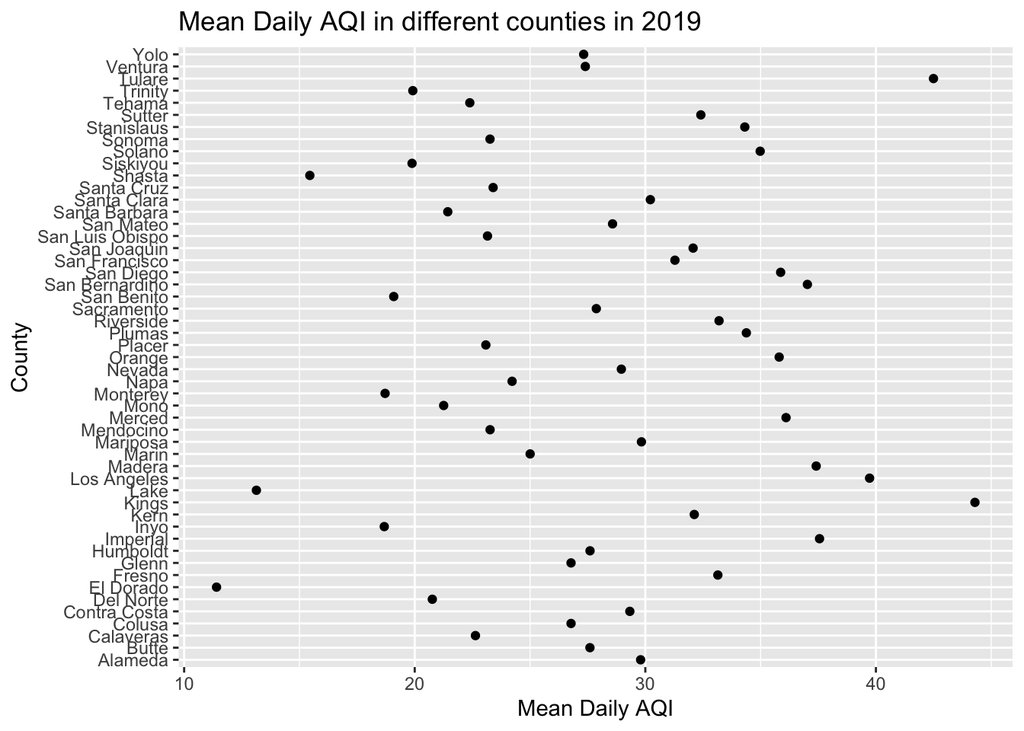

```r
Mean2019<-ddply(PMdata2019,.(COUNTY),summarize,meanValue=mean(DAILY_AQI_VALUE))
ggplot(data=Mean2019, aes(x=Mean2019$meanValue,y=Mean2019$COUNTY))+geom_point()+labs(title="Mean Daily AQI in different counties in 2019")+xlab("Mean Daily AQI")+ylab("County")
```

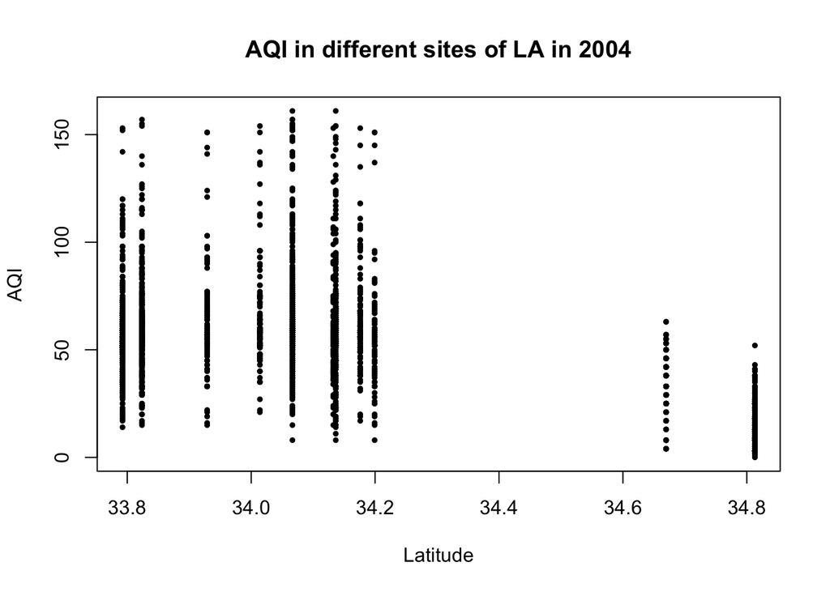

```r
#LA
LosAngeles2004 = PMdata2004[COUNTY == "Los Angeles", .(SITE_LATITUDE, DAILY_AQI_VALUE)]
plot(LosAngeles2004$SITE_LATITUDE, LosAngeles2004$DAILY_AQI_VALUE, pch=19, cex=0.5,
     main="AQI in different sites of LA in 2004",
     xlab="Latitude", ylab="AQI")
```

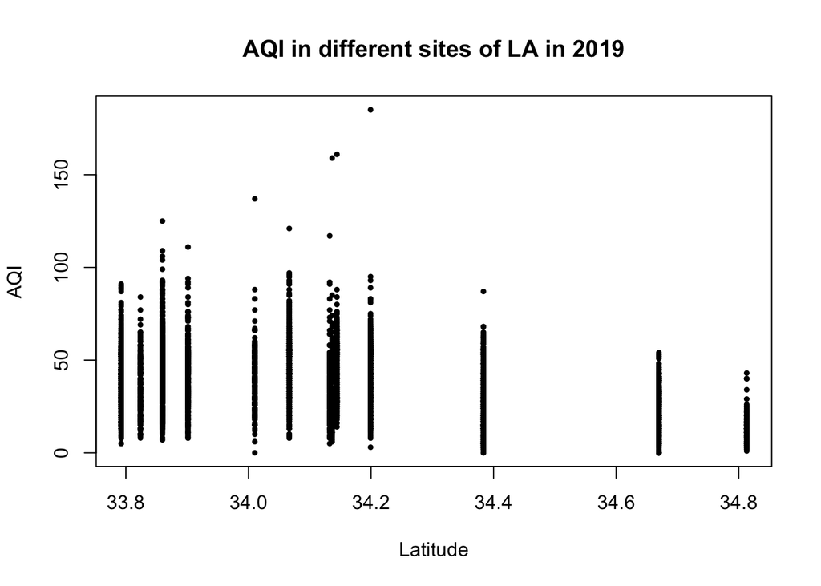

```r
LosAngeles2019 = PMdata2019[COUNTY == "Los Angeles", .(SITE_LATITUDE, DAILY_AQI_VALUE)]
plot(LosAngeles2019$SITE_LATITUDE, LosAngeles2019$DAILY_AQI_VALUE, pch=19, cex=0.5,
     main="AQI in different sites of LA in 2019",
     xlab="Latitude", ylab="AQI")
```

```r
names(sort(-table(LosAngeles2004$DAILY_AQI_VALUE)))[1]
```

```
## [1] "52"
```

```r
names(sort(-table(LosAngeles2019$DAILY_AQI_VALUE)))[1]
```

```
## [1] "40"
```

##Daily AQI in different sites of LA are slightly different. It clearly shows that AQI in LA in 2019 is lower than that in 2004. The mode of AQI in LA decreased from 52 in 2004 to 40 in 2019.